# DataExploratoryAnalysis

```python
import pandas as pd
import numpy as np
import os
import matplotlib.pyplot as plt
import seaborn as sns
import warnings
%matplotlib inline
warnings.filterwarnings("ignore")
```

```python
curr_dir = os.getcwd()
data_path = os.path.join(curr_dir, r"datasets", r"listings_raw.csv")
df = pd.read_csv(data_path)
```

```python
df.shape
```

```
(83850, 106)
```

```python
df.sample(5)
```

|  | id | listing_url | scrape_id | last_scraped | name | summary | space | description | experiences_offered | neighborhood_overview | ... | instant_bookable | is_business_travel_ready | cancellation_policy | require_guest_profile_picture | require_guest_phone_verification | calculated_host_listings_count | calculated_host_listings_count_entire_homes | calculated_host_listings_count_private_rooms | calculated_host_listings_count_shared_rooms | reviews_per_month |
| --- | --- | --- | --- | --- | --- | --- | --- | --- | --- | --- | --- | --- | --- | --- | --- | --- | --- | --- | --- | --- | --- |
| 30722 | 18251019 | https://www.airbnb.com/rooms/18251019 | 20190710134553 | 2019-07-11 | Peaceful apartment in Muswell Hill sleeps up to 4 | Peaceful first floor apartment backing onto la... | This is a lovely, quiet first floor flat with ... | Peaceful first floor apartment backing onto la... | none | Muswell Hill is a lovely quiet area of London ... | ... | f | f | flexible | f | f | 1 | 1 | 0 | 0 | 3.33 |
| 19111 | 12847396 | https://www.airbnb.com/rooms/12847396 | 20190710134553 | 2019-07-11 | Cosy bright room in Zone 2 London | A compact and nice bedroom in a house shared w... | NaN | A compact and nice bedroom in a house shared w... | none | NaN | ... | f | f | flexible | f | f | 1 | 0 | 1 | 0 | 0.05 |
| 17585 | 11810315 | https://www.airbnb.com/rooms/11810315 | 20190710134553 | 2019-07-11 | Double sofa bed in spacious room | Situated in a quiet and friendly neighborhood,... | The room you will stay in is the largest in th... | Situated in a quiet and friendly neighborhood,... | none | Lovely neighborhood, friendly, lots of green a... | ... | t | f | flexible | f | f | 1 | 0 | 1 | 0 | 0.35 |
| 5320 | 3832145 | https://www.airbnb.com/rooms/3832145 | 20190710134553 | 2019-07-11 | En Suite Double Room in Bounds Green -North Lo... | Large en suite double room available in a 3-be... | Spacious EN SUITE double room in a very quiet ... | Large en suite double room available in a 3-be... | none | Bounds Green is a very leafy neighbourhood, wi... | ... | f | f | moderate | f | f | 3 | 0 | 3 | 0 | 0.24 |
| 50128 | 25183285 | https://www.airbnb.com/rooms/25183285 | 20190710134553 | 2019-07-12 | Bright, Modern Apartment in the Heart of Wimbl... | Modern and stylish ground floor apartment with... | This apartment has everything you need to make... | Modern and stylish ground floor apartment with... | none | Famous for its annual tennis tournament, Wimbl... | ... | t | f | moderate | f | f | 1 | 1 | 0 | 0 | 0.24 |

5 rows × 106 columns

## Checking how large the file source is

```python
df.info(memory_usage='deep')
```

```
<class 'pandas.core.frame.DataFrame'>
RangeIndex: 83850 entries, 0 to 83849
Columns: 106 entries, id to reviews_per_month
dtypes: float64(23), int64(21), object(62)
memory usage: 629.6 MB
```

```python
df.memory_usage(deep=True).sort_values(ascending=False)
```

```
description               84055518
space                     38135860
summary                   35965488
neighborhood_overview     33754138
amenities                 31014271
                            ...
minimum_minimum_nights      670800
maximum_minimum_nights      670800
minimum_maximum_nights      670800
maximum_maximum_nights      670800
Index                          128
Length: 107, dtype: int64
```

## Data Cleaning: Missing values and data inconsistency check

```python
# Find most correlated numerical features wrt to house price
# Use linear regression model to get a baseline model
# Then do an EDA
# Find unique values by column
# Missing value check on price
# Convert dollar string to float
# Plot
percent_missing = df.isnull().sum() * 100 / len(df)
percent_missing.sort_values(ascending=False)
```

```
thumbnail_url                   100.0
neighbourhood_group_cleansed    100.0
xl_picture_url                  100.0
host_acceptance_rate            100.0
medium_url                      100.0
                                ...
maximum_nights                    0.0
minimum_minimum_nights            0.0
maximum_minimum_nights            0.0
minimum_maximum_nights            0.0
id                                0.0
Length: 106, dtype: float64
```

```python
percent_missing[percent_missing > 0] # With more than 0% missing values
```

```
name                              0.031008
summary                           4.622540
space                            30.516398
description                       2.174120
neighborhood_overview            36.319618
notes                            60.960048
transit                          36.741801
access                           44.669052
interaction                      41.790101
house_rules                      41.742397
thumbnail_url                   100.000000
medium_url                      100.000000
xl_picture_url                  100.000000
host_name                         0.056052
host_since                        0.056052
host_location                     0.295766
host_about                       42.094216
host_response_time               29.555158
host_response_rate               29.555158
host_acceptance_rate            100.000000
host_is_superhost                 0.056052
host_thumbnail_url                0.056052
host_picture_url                  0.056052
host_neighbourhood               22.909958
host_listings_count               0.056052
host_total_listings_count         0.056052
host_has_profile_pic              0.056052
host_identity_verified            0.056052
neighbourhood                     0.001193
neighbourhood_group_cleansed    100.000000
city                              0.158617
state                            20.087060
zipcode                           2.323196
market                            1.008945
bathrooms                         0.164580
bedrooms                          0.040549
beds                              0.166965
square_feet                      99.469290
weekly_price                     91.073345
monthly_price                    93.645796
security_deposit                 35.152057
cleaning_fee                     25.726893
first_review                     25.072153
last_review                      25.072153
review_scores_rating             27.059034
review_scores_accuracy           27.119857
review_scores_cleanliness        27.106738
review_scores_checkin            27.183065
review_scores_communication      27.116279
review_scores_location           27.181872
review_scores_value              27.181872
license                          99.769827
jurisdiction_names               99.997615
reviews_per_month                25.072153
dtype: float64
```

```python
percent_missing[percent_missing == 0] # With no missing values
```

```
id                                              0.0
listing_url                                     0.0
scrape_id                                       0.0
last_scraped                                    0.0
experiences_offered                             0.0
picture_url                                     0.0
host_id                                         0.0
host_url                                        0.0
host_verifications                              0.0
street                                          0.0
neighbourhood_cleansed                          0.0
smart_location                                  0.0
country_code                                    0.0
country                                         0.0
latitude                                        0.0
longitude                                       0.0
is_location_exact                               0.0
property_type                                   0.0
room_type                                       0.0
accommodates                                    0.0
bed_type                                        0.0
amenities                                       0.0
price                                           0.0
guests_included                                 0.0
extra_people                                    0.0
minimum_nights                                  0.0
maximum_nights                                  0.0
minimum_minimum_nights                          0.0
maximum_minimum_nights                          0.0
minimum_maximum_nights                          0.0
maximum_maximum_nights                          0.0
minimum_nights_avg_ntm                          0.0
maximum_nights_avg_ntm                          0.0
calendar_updated                                0.0
has_availability                                0.0
availability_30                                 0.0
availability_60                                 0.0
availability_90                                 0.0
availability_365                                0.0
calendar_last_scraped                           0.0
number_of_reviews                               0.0
number_of_reviews_ltm                           0.0
requires_license                                0.0
instant_bookable                                0.0
is_business_travel_ready                        0.0
cancellation_policy                             0.0
require_guest_profile_picture                   0.0
require_guest_phone_verification                0.0
calculated_host_listings_count                  0.0
calculated_host_listings_count_entire_homes     0.0
calculated_host_listings_count_private_rooms    0.0
calculated_host_listings_count_shared_rooms     0.0
dtype: float64
```

```python
cols_to_drop = percent_missing[percent_missing > 90].index # Drop cols with more than 90% missing vals
df.drop(cols_to_drop, axis=1, inplace=True)
```

```python
df.nunique().sort_values(ascending=True)
```

```
scrape_id                       1
has_availability                1
is_business_travel_ready        1
host_identity_verified          2
is_location_exact               2
                            ...
description                 77969
name                        81547
picture_url                 82312
listing_url                 83850
id                          83850
Length: 96, dtype: int64
```

```python
# Remove all columns with URLs, as initial baseline model will not consider these
df = df.loc[:, ~df.columns.str.contains('url')]
```

```python
# Manually checking all price data. Seems like they are all object/string types hence
# need to be converted to floats
df[["price", "security_deposit", "cleaning_fee", "extra_people"]].sample(10)
```

|  | price | security_deposit | cleaning_fee | extra_people |
| --- | --- | --- | --- | --- |
| 35388 | $35.00 | $0.00 | $10.00 | $10.00 |
| 14192 | $55.00 | $300.00 | $50.00 | $30.00 |
| 22675 | $32.00 | NaN | NaN | $0.00 |
| 12703 | $160.00 | $150.00 | $30.00 | $0.00 |
| 45850 | $260.00 | $495.00 | $300.00 | $0.00 |
| 19539 | $90.00 | $250.00 | $40.00 | $10.00 |
| 25291 | $45.00 | $0.00 | $25.00 | $10.00 |
| 37578 | $75.00 | NaN | NaN | $0.00 |
| 42398 | $90.00 | NaN | $40.00 | $15.00 |
| 23670 | $25.00 | $200.00 | $10.00 | $10.00 |

```python
cols = ["price", "security_deposit", "cleaning_fee", "extra_people"]
df[cols].info()
```

```
<class 'pandas.core.frame.DataFrame'>
RangeIndex: 83850 entries, 0 to 83849
Data columns (total 4 columns):
price               83850 non-null object
security_deposit    54375 non-null object
cleaning_fee        62278 non-null object
extra_people        83850 non-null object
dtypes: object(4)
memory usage: 2.6+ MB
```

```python
for col in cols:
    df[col] = df[col].astype(str).str.extract("(\d+)").astype(float)
```

```python
df_base = df.copy() # Create a copy of the original dataframe
```

```python
def fillna(series):
    if series.dtype is pd.np.dtype(float):
        return series.fillna(0)
    elif series.dtype is pd.np.dtype(object):
        return series.fillna('.')
    else:
        return series
```

```python
df_base = df_base.apply(fillna)
```

```python
df_base.isnull().sum() * 100 / len(df_base) # check missing values
```

```
id                                              0.0
scrape_id                                       0.0
last_scraped                                    0.0
name                                            0.0
summary                                         0.0
                                               ...
calculated_host_listings_count                  0.0
calculated_host_listings_count_entire_homes     0.0
calculated_host_listings_count_private_rooms    0.0
calculated_host_listings_count_shared_rooms     0.0
reviews_per_month                               0.0
Length: 91, dtype: float64
```

```python
# save sample of the dataset to examine manually on disk to answer some business questions about the dataset
df_base.sample(5).to_csv(os.path.join(curr_dir, r"datasets", r"listings_clean_sample.csv"), index=False)
```

```python
pd.set_option('display.max_columns', 500)
sample = pd.read_csv(os.path.join(curr_dir, r"datasets", r"listings_clean_sample.csv"))
sample.head()
```

|  | id | scrape_id | last_scraped | name | summary | space | description | experiences_offered | neighborhood_overview | notes | transit | access | interaction | house_rules | host_id | host_name | host_since | host_location | host_about | host_response_time | host_response_rate | host_is_superhost | host_neighbourhood | host_listings_count | host_total_listings_count | host_verifications | host_has_profile_pic | host_identity_verified | street | … |
| --- | --- | --- | --- | --- | --- | --- | --- | --- | --- | --- | --- | --- | --- | --- | --- | --- | --- | --- | --- | --- | --- | --- | --- | --- | --- | --- | --- | --- | --- | --- |
| 0 | 32401015 | 20190710134553 | 2019-07-12 | London Room for up to 4 people | 4 comfy beds in a beautiful, bright, fresh bed... | There are 2 bunk beds for 4 guests in a Large ... | 4 comfy beds in a beautiful, bright, fresh bed... | none | The house is set on a tranquil street close to... | . | London Bridge and Charing Cross is 15 - 25 min... | . | The host will be available during your stay fo... | - No outdoor shoes in the house | 243307844 | Barbara | 2019-02-15 | London, England, United Kingdom | I am fun, bubbly and always willing to accommo... | within a few hours | 95% | f | Catford | 3.0 | 3.0 | ['email', 'phone'] | t | f | Greater London, England, United Kingdom | … |
| 1 | 19180583 | 20190710134553 | 2019-07-11 | Large Apartment near Airport & Mall (Shared Room) | From the train station you can get to a vast a... | 7 minutes walk to the train station and shoppi... | From the train station you can get to a vast a... | none | . | Gatwick Airport is 15 Minutes by train just ge... | . | Kitchen, Bathroom and Living Room and dining a... | I am here if you need help with anything. | 1) No Shoes allowed in the house 2) Wash Bath ... | 48030900 | Ms | 2015-11-03 | United Kingdom | I am self-employed, salsa dancing individual,... | . | . | f | LB of Croydon | 6.0 | 6.0 | ['email', 'phone', 'reviews', 'jumio', 'offlin... | t | f | Greater London, England, United Kingdom | … |
| 2 | 22255826 | 20190710134553 | 2019-07-11 | Cosy 1Bed Apt in Holloway- Light & Spacious | Lovely 1-bedroom, 1-bathroom flat in the fabul... | Amenities: - Professionally cleaned - Hotel-qu... | Lovely 1-bedroom, 1-bathroom flat in the fabul... | none | Holloway is one of the liveliest and most cosm... | . | Holloway has excellent transport links with Ho... | Guests will have access to the entire property... | My support team or I will be contactable by em... | - Please treat the home as you would your own.... | 161949582 | Sam | 2017-12-09 | GB | . | within a day | 80% | t | . | 1.0 | 1.0 | ['email', 'phone', 'reviews', 'jumio', 'offlin... | t | f | Greater London, England, United Kingdom | … |
| 3 | 14941541 | 20190710134553 | 2019-07-11 | Lovely Single Bedroom in London - Near Big Ben | A large, modern single bedroom with double bed... | Our member of staffs goal is to offer the gues... | A large, modern single bedroom with double bed... | none | . | . | . | . | . | - No smoking(including E-cig) in the house. Th... | 93646755 | Sarah | 2016-09-05 | London, England, United Kingdom | Hi, I am Sarah- English/Korean who has been li... | within an hour | 100% | f | Lambeth | 4.0 | 4.0 | ['email', 'phone', 'reviews', 'jumio', 'offlin... | t | f | London, England, United Kingdom | … |
| 4 | 32740068 | 20190710134553 | 2019-07-11 | Stunning Brand New Home in Canary Wharf | Set in Canary Wharf, step away from the busy s... | MASTER BED - King size bed with luxury 500tc s... | Set in Canary Wharf, step away from the busy s... | none | Canary Wharf is a busy financial area filled w... | . | TRAINS & UNDERGROUND STATIONS - Crossharbour ... | . | We are available over text or call whenever yo... | - No shoes in the house - Respectful of neighb... | 46362642 | Kelly | 2015-10-12 | GB | Hello, I'm Kelly! Welcome to my hosting profil... | within an hour | 97% | t | Westbourne Green | 12.0 | 12.0 | ['email', 'phone', 'facebook', 'reviews', 'jum... | t | f | Greater London, England, United Kingdom | … |

## Some key business questions

**Based on manually examining the sample dataset above, we will address the following key questions in order to understand the data more from a business perspective:**

1. What is the size of the dataset and from what period was the data scraped between?
2. How many unique hosts are there and what is the distribution of listing price?
3. How many unique property or room types are there and what is the average/median price?
4. Do the number of accomodates, bathrooms, bedrooms, beds or bed type have any effect on the price? Do they follow a distribution of prices?
5. Show top 10 hosts with a breakdown of number of listings, average listing price, number of reviews, min and max nights allowed, avg cleaning fee, avg security deposit?
6. Does strictness of house rules have any effect on the price?
7. What are the top 10 most common words in the name and the summary for the listings?
8. Does mention of vicinity to public transport or town centre have any effect on the average price (breakdown by rail/train, bus, walking distance to town centre etc.?
9. Do the number of included amenities affect price?
10. Show a breakdown by neighbourhood, the top 5 hosts with the most number of listed properties and their average price
11. Visualise the price distribution by location using google maps

### 0. What is the size of the dataset and from what period was the data scraped between?

```python
df["last_scraped"] = pd.to_datetime(df["last_scraped"]) # convert last scraped column to datetime object
```

```python
def min_max_date_diff(df):
    """
    Returns time delta object taking difference between
    max and min date in a pandas column.
    """
    return df.max() - df.min()

print("Total records: {}, Scrape Duration: {}".format(df.shape[0], min_max_date_diff(df["last_scraped"])))
print("Between {} - {}".format(df["last_scraped"].min(), df["last_scraped"].max()))
```

```
Total records: 83850, Scrape Duration: 2 days 00:00:00
Between 2019-07-10 00:00:00 - 2019-07-12 00:00:00
```

### 1. How many unique hosts are there and what is the distribution of listing price?

```python
# unique hosts
df["host_id"].nunique()
```

```
53342
```

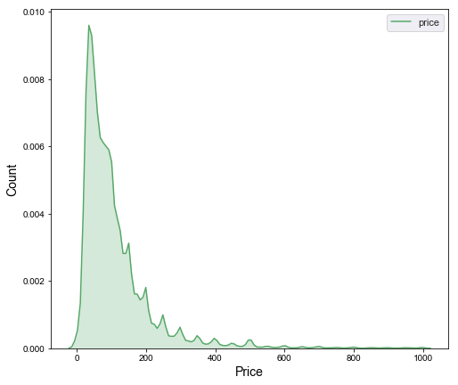

```
Mean: $110.42, Sigma: $104.68
```

```python
def distribution_stats(df):
    """
    Returns mean and sample standard deviation
    of pandas dataframe.
    """
    print("Mean: ${:.2f}, Sigma: ${:.2f}".format(df.mean(), df.std()))

f, ax = plt.subplots(figsize=(8, 7))
sns.set(color_codes=True)
sns.kdeplot(df["price"], shade=True, color="g", label="price")
plt.ylabel("Count", fontsize=14)
plt.xlabel("Price", fontsize=14)
plt.show()
distribution_stats(df["price"])
```

### 2. How many unique property or room types are there and what is the average/median price?

```python
# Unique properties
df["property_type"].nunique()
```

```
40
```

```python
df["room_type"].nunique()
```

```
3
```

```python
df.groupby(["property_type"]).agg({"price":"median"}).sort_values("price", ascending=True)
```

| property_type | price |
| --- | --- |
| Parking Space | 20.0 |
| Hostel | 25.0 |
| Earth house | 31.5 |
| Treehouse | 32.5 |
| Ryokan (Japan) | 35.0 |
| Bus | 37.5 |
| Dome house | 40.0 |
| Casa particular (Cuba) | 45.0 |
| Farm stay | 49.0 |
| Campsite | 50.0 |
| House | 50.0 |
| Bungalow | 50.0 |
| Yurt | 52.0 |
| Other | 55.0 |
| Bed and breakfast | 58.0 |
| Guest suite | 58.5 |
| Hut | 59.0 |
| Cabin | 59.5 |
| Townhouse | 60.0 |
| Villa | 60.0 |
| Tent | 65.0 |
| Tiny house | 65.0 |
| Guesthouse | 65.0 |
| Chalet | 65.0 |
| Houseboat | 69.0 |
| Camper/RV | 70.0 |
| Cottage | 77.0 |
| Lighthouse | 78.0 |
| Island | 79.0 |
| Condominium | 80.0 |
| Loft | 85.0 |
| Apartment | 89.0 |
| Boat | 92.0 |
| Barn | 92.5 |
| Aparthotel | 100.0 |
| Hotel | 116.0 |
| Boutique hotel | 120.0 |
| Serviced apartment | 140.0 |
| Plane | 150.0 |
| Nature lodge | 174.5 |

Based on the property_type aggregation above, we can see that the median price is lowest for parking spaces and the highest for Nature lodges.

```
                 price
room_type
Shared room       27.0
Private room      45.0
Entire home/apt  120.0
```

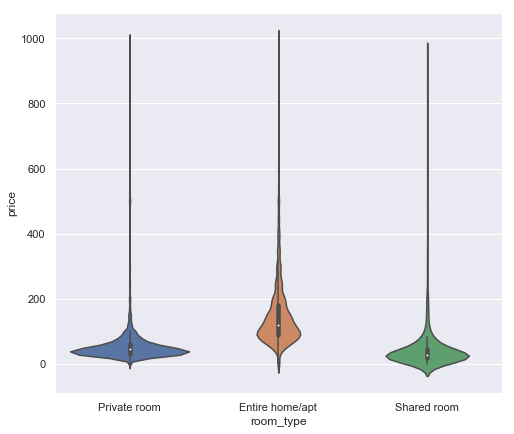

```python
f, ax = plt.subplots(figsize=(8, 7))
sns.violinplot(x="room_type", y="price", data=df)

print(df.groupby(["room_type"]).agg({"price":"median"}).sort_values("price", ascending=True))
```

Based on the violin plots, the distributions are non-normal, with very long tails towards higher prices. The width of the violin plot is the mode. The median was chosen as the metric as it is least likely to be affected by outliers than the average. Based on the room_type grouping, Entire homes/apt generally tends have a higher median price nearly 5 times higher than for shared rooms.

### 3. Do the number of accomodates, bathrooms, bedrooms, beds or bed type have any effect on the price? Do they follow a distribution of prices?

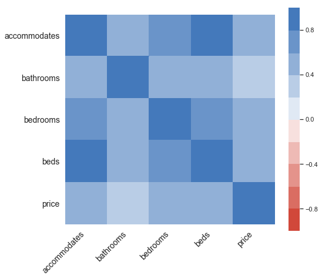

```
price           1.000000
accommodates    0.547326
bedrooms        0.494884
beds            0.442961
bathrooms       0.395363
Name: price, dtype: float64
```

```python
corr = df[["accommodates", "bathrooms", "bedrooms", "beds", "bed_type", "price"]].corr()
def correlation_heat_map(corr):
    f, ax = plt.subplots(figsize=(8, 7))
    ax = sns.heatmap(corr, vmin=-1, vmax=1, center=0,
                    cmap=sns.diverging_palette(15, 250, n=10),
                    square=True)
    ax.set_xticklabels(
        ax.get_xticklabels(),
        rotation=45,
        horizontalalignment="right",
        fontsize=14)
    ax.set_yticklabels(ax.get_xticklabels(), fontsize=14)
    plt.show()
    return corr["price"].sort_values(ascending=False)
print(correlation_heat_map(corr))
```

```python
# missing values
df["accommodates"].isnull().sum(), df["beds"].isnull().sum()
```

```
(0, 140)
```

[output not shown]

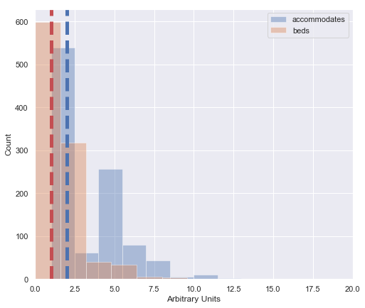

```python
from scipy.stats import f_oneway
from scipy.stats import ttest_ind

plt.figure(figsize=(8, 7))
sample_size = 1000
acc = np.random.choice(df_base["accommodates"], sample_size)
beds = np.random.choice(df_base["beds"], sample_size)
ax1 = sns.distplot(acc, bins=10, kde=False, label="accommodates")
ax2 = sns.distplot(beds, bins=10, kde=False, label="beds")
plt.axvline(np.median(acc), color="b", linestyle="dashed", linewidth=5)
plt.axvline(np.median(beds), color="r", linestyle="dashed", linewidth=5)
plt.xlabel("Arbitrary Units")
plt.ylabel("Count")
plt.legend()
plt.xlim(0, 20)
```

```python
np.random.seed(42)
def students_t_test(arr1, arr2, alpha, sample_size):
    """
    Two-sided students-t-test for the null hypothesis that 2 independent
    samples have identical average values. Assumes populations have identical
    variance.
    """
    arr1 = np.random.choice(arr1, sample_size)
    arr2 = np.random.choice(arr2, sample_size)
    stat, p = ttest_ind(arr1, arr2)
    print("T-statistic: {:.4f}, p: {:.4f}".format(stat, p))
    if p > alpha:
        print("Fail to reject H0")
    else:
        print("Different distributions (Reject H0)")

sample_size = 1000 # take a random sample
students_t_test(acc, beds, 0.05, sample_size)
```

```
T-statistic: 21.8478, p: 0.0000
Different distributions (Reject H0)
```

Based on the above t-test, accommodates have different means to beds, hence must keep this in mind for feature engineering and model building later. However, since the distributions are not normal (accommodates seems to follow a bimodal dist) and has many outliers, the t-test was not the best choice here as it assumes normality. The Wilcoxon rank-sum test (also known as the Mann–Whitney U test) can be used instead for non-normal data. But for now, it will not be implemented due to its complexity.

```
               price
bed_type
Futon           45.0
Pull-out Sofa   50.0
Couch           55.0
Airbed          70.0
Real Bed        80.0
```

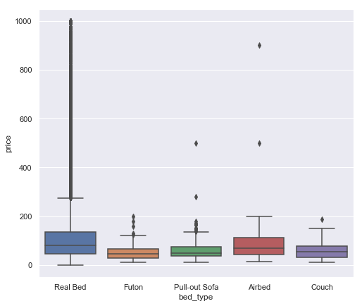

```python
f, ax = plt.subplots(figsize=(8, 7))
sns.boxplot(x="bed_type", y="price", data=df)
print(df.groupby(["bed_type"]).agg({"price":"median"}).sort_values("price"))
```

Box plot for bed_type shows that listings with futon bed_type command a lower median price than real beds. For the latter, there is considerable variability on the higher end above IQR compared to other bed types.

### 4. Show top 10 hosts with a breakdown of number of listings, average listing price, number of reviews, min and max nights allowed, avg cleaning fee, avg security deposit?

```python
aggs = {"host_id" : "count",
       "number_of_reviews" : "sum",
        "minimum_nights" : "mean",
        "maximum_nights" : "mean",
        "security_deposit" : "mean",
        "cleaning_fee" : "mean",
       "price" : "mean"}

result = df.groupby(["host_id"]).agg(aggs)
result.rename(columns={"host_id" : "num_of_listings"}, inplace=True)
result.sort_values(by="num_of_listings", ascending=False).reset_index().head(10)
```

|  | host_id | num_of_listings | number_of_reviews | minimum_nights | maximum_nights | security_deposit | cleaning_fee | price |
| --- | --- | --- | --- | --- | --- | --- | --- | --- |
| 0 | 33889201 | 1161 | 1084 | 2.649440 | 1124.030146 | 499.829457 | 194.137069 | 264.880276 |
| 1 | 156158778 | 263 | 37 | 1.000000 | 1125.000000 | 2.216730 | 0.000000 | 489.958175 |
| 2 | 28820321 | 213 | 2333 | 2.258216 | 1114.478873 | 287.089202 | 74.131455 | 122.539906 |
| 3 | 137094377 | 177 | 20 | 5.135593 | 1125.000000 | 494.829545 | 177.238636 | 313.372881 |
| 4 | 48165024 | 164 | 498 | 4.445122 | 1125.000000 | 17.777778 | 36.888889 | 158.189024 |
| 5 | 1432477 | 161 | 1500 | 1.664596 | 1125.000000 | 248.453416 | 87.453416 | 202.503106 |
| 6 | 27572615 | 136 | 613 | 5.625000 | 1100.455882 | 289.750000 | 126.383459 | 257.176471 |
| 7 | 224866971 | 114 | 406 | 2.000000 | 1125.000000 | 320.175439 | 85.614035 | 313.526316 |
| 8 | 50291093 | 113 | 182 | 6.991150 | 1124.893805 | 250.000000 | 0.000000 | 141.619469 |
| 9 | 83740964 | 102 | 3196 | 14.794118 | 153.117647 | 0.000000 | 0.000000 | 99.470588 |

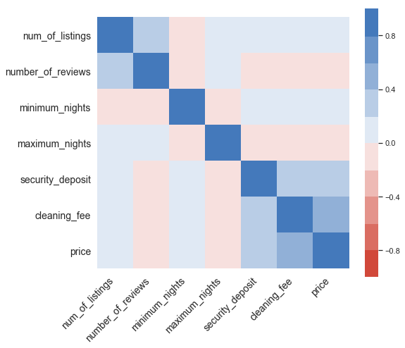

```
price                1.000000
cleaning_fee         0.543595
security_deposit     0.243682
num_of_listings      0.050522
minimum_nights       0.019368
maximum_nights      -0.001385
number_of_reviews   -0.011435
Name: price, dtype: float64
```

```python
corr = result.corr()
correlation_heat_map(corr)
```

Looking at the above visualisations, there does not seem to be any relationship between the variables to the price other than perhaps cleaning_fee, which shows a moderate correlation of 0.544.

### 5. Does strictness of house rules have any effect on the price?

```python
df_base["house_rules"] = df_base["house_rules"].str.lower() # convert house_rules to lower case
```

```
120.0 79.0
1000 1000
```

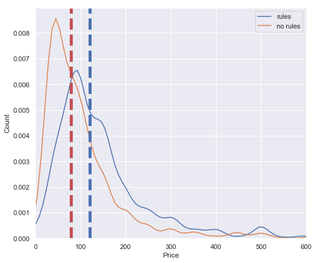

```python
rules = ["no pets", "no parties"]

rules_df = df_base[df_base["house_rules"]\
                       .apply(lambda sentence: any(pattern in sentence for pattern in rules))]
no_rules_df = df_base[~df_base["house_rules"]\
                          .apply(lambda sentence: any(pattern in sentence for pattern in rules))]

sample_size = 1000
rules_df = np.random.choice(rules_df["price"], sample_size)
no_rules_df = np.random.choice(no_rules_df["price"], sample_size)
plt.figure(figsize=(8, 7))
ax1 = sns.kdeplot(rules_df, bw=15, label="rules")
ax2 = sns.kdeplot(no_rules_df, bw=15, label="no rules")
plt.axvline(np.median(rules_df), color="b", linestyle="dashed", linewidth=5)
plt.axvline(np.median(no_rules_df), color="r", linestyle="dashed", linewidth=5)
plt.xlabel("Price")
plt.ylabel("Count")
plt.legend()
plt.xlim(0, 600)

print(np.median(rules_df), np.median(no_rules_df))
print(rules_df.shape[0], no_rules_df.shape[0])
```

Distributions are heavily right-tailed skewed, and by eye we can see that stricter house_rules like "no parties" or "no pets" tend to have a higher median listing price than non-strict house_rules. Can maybe use Mann–Whitney test to confirm quantitatively the difference between the distributions. Deep dive into how the price differs between different set of rules can be a later exercise.

### 6. What are the top 10 most common words in the name and the summary for the listings?

```python
# !pip install wordcloud
```

```python
from itertools import cycle, islice
from nltk.corpus import stopwords
from wordcloud import WordCloud, STOPWORDS, ImageColorGenerator

stops = set(stopwords.words("english"))
stops.update(["&", "1", "2", "3", "4",
             "5", "6", "7", "8", "9",
             "0", "bed", "bedroom", "flat",
             "apartment", "house", "london",
             "db", "w1", "ap", "app", "one",
             "two", "three", "four", "five",
             "room", "-", "double", "near", "home", "house",
             "private", "studio", "zone", "single",
             "bathroom", "central"])

common_names = " ".join([word for word in " ".join(df_base['name']).lower().split() if word not in stops])
common_summary = " ".join([word for word in " ".join(df_base['name']).lower().split() if word not in stops])
```

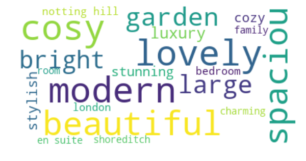

```python
wordcloud = WordCloud(max_font_size=50, max_words=20, background_color="white").generate(common_names)
plt.figure(figsize=(10, 10))
plt.imshow(wordcloud, interpolation="bilinear")
plt.axis("off")
plt.show()
```

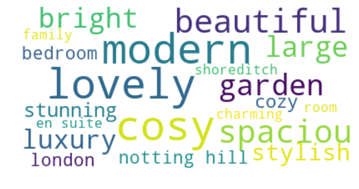

```python
wordcloud = WordCloud(max_font_size=50, max_words=20, background_color="white").generate(common_summary)
plt.figure(figsize=(10, 10))
plt.imshow(wordcloud, interpolation="bilinear")
plt.axis("off")
plt.show()
```

```python
pd.Series([word for word in " "\
           .join(df_base['name'])\
           .lower().split() if word not in stops])\
           .value_counts()[:10]
```

```
spacious     5639
modern       5179
bright       4354
lovely       4319
garden       4251
cosy         4148
beautiful    4046
large        3418
park         3014
luxury       2570
dtype: int64
```

### 7. Does mention of vicinity to public transport have any effect on the average price?

```
79.0 85.0
1000 1000
```

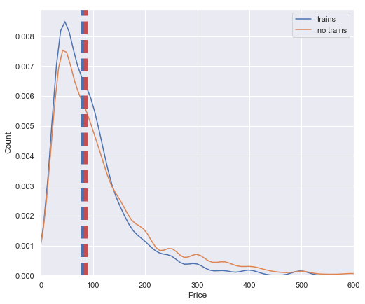

```python
rules = ["train", "tube", "rail", "station"]

rules_df = df_base[df_base["summary"]\
                       .apply(lambda sentence: any(pattern in sentence for pattern in rules))]
no_rules_df = df_base[~df_base["summary"]\
                          .apply(lambda sentence: any(pattern in sentence for pattern in rules))]


sample_size = 1000
rules_df = np.random.choice(rules_df["price"], sample_size)
no_rules_df = np.random.choice(no_rules_df["price"], sample_size)
plt.figure(figsize=(8, 7))
ax1 = sns.kdeplot(rules_df, bw=15, label="trains")
ax2 = sns.kdeplot(no_rules_df, bw=15, label="no trains")
plt.axvline(np.median(rules_df), color="b", linestyle="dashed", linewidth=5)
plt.axvline(np.median(no_rules_df), color="r", linestyle="dashed", linewidth=5)
plt.xlabel("Price")
plt.ylabel("Count")
plt.legend()
plt.xlim(0, 600)

print(np.median(rules_df), np.median(no_rules_df))
print(rules_df.shape[0], no_rules_df.shape[0])
```

On the surface, there does not appear to be any significant variation in the price if train related vocabulary is present in the summary. London has an extensive and extremely well connected system of trains and underground tube system, hence this result may not be too surprising. Perhaps there may be a variation if we look deeper into the location as the further away a property is from the train station, there may be fewer occurences of train related vocab in the summary

### 8. Do the number of included amenities affect price?

```python
def convert_to_arr(series):
    series = series.replace("{", "")
    series = series.replace("}", "")
    return len(series.split(","))
df_base["amenities_len"] = df_base["amenities"].apply(convert_to_arr)
```

```python
corr = df_base[["price", "amenities_len"]].corr()
corr
```

|  | price | amenities_len |
| --- | --- | --- |
| price | 1.000000 | 0.146531 |
| amenities_len | 0.146531 | 1.000000 |

It seems there is a very weak positive correlation, but it is not very signifcant. There may be certain special features present in the amenities that may affect the price, but we will not investigate too deeply here.

### 9. Show a breakdown by neighbourhood, the top 5 hosts with the most number of listed properties and their average price

```python
group_cols = ["neighbourhood_cleansed", "host_id"]

aggs = {"neighbourhood_cleansed" : "count",
        "price" : "mean"}

result = df_base.groupby(group_cols).agg(aggs)

result\
    .rename(columns={"neighbourhood_cleansed" : "num_of_props"},
              inplace=True)

result = result\
    .sort_values(["neighbourhood_cleansed",
                  "num_of_props",
                  "price"],
                   ascending=[True, False, False])

result.reset_index(inplace=True)
```

```python
result.groupby("neighbourhood_cleansed").head(5).head(10).reset_index(drop="index") # Just displaying the first 2 groups
```

|  | neighbourhood_cleansed | host_id | num_of_props | price |
| --- | --- | --- | --- | --- |
| 0 | Barking and Dagenham | 27774033 | 7 | 90.714286 |
| 1 | Barking and Dagenham | 189726472 | 4 | 31.250000 |
| 2 | Barking and Dagenham | 183841172 | 3 | 230.000000 |
| 3 | Barking and Dagenham | 19826493 | 3 | 167.333333 |
| 4 | Barking and Dagenham | 196331237 | 3 | 93.333333 |
| 5 | Barnet | 48165024 | 20 | 82.500000 |
| 6 | Barnet | 163007820 | 12 | 101.250000 |
| 7 | Barnet | 33889201 | 10 | 307.300000 |
| 8 | Barnet | 17453098 | 9 | 81.666667 |
| 9 | Barnet | 103394542 | 8 | 170.625000 |

```python
# Unique neighbourhoods
len(result["neighbourhood_cleansed"].unique())
```

```
33
```

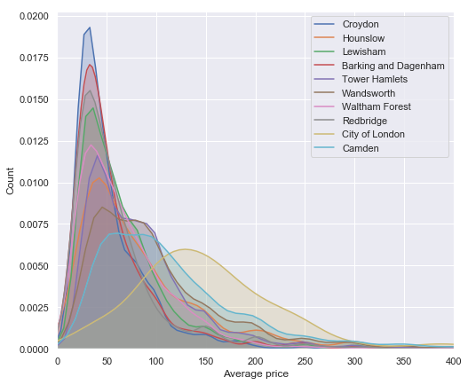

```python
np.random.seed(6)
f, ax = plt.subplots(figsize=(8, 7))
neighbourhoods = np.random.choice(result["neighbourhood_cleansed"].unique(), 10, replace=False)
for n in neighbourhoods:
    sns.kdeplot(result[result["neighbourhood_cleansed"] == n]["price"],
                shade=True, label=n).set(xlim=(0))
plt.xlim(0, 400)
plt.xlabel("Average price")
plt.ylabel("Count")
plt.show()
```

Based on the above aggregation and distribution plots (based on random samples since there are 33 neighbourhoods), we can see that there are considerable differences in the average price dependent on the neighbourhood.

### 10. Visualise the price distribution by location using Google maps API

```python
# !pip install gmaps
```

```python
!jupyter nbextension enable --py --sys-prefix widgetsnbextension
!jupyter nbextension enable --py --sys-prefix gmaps
```

```
Enabling notebook extension jupyter-js-widgets/extension...
      - Validating: ok
Enabling notebook extension jupyter-gmaps/extension...
      - Validating: ok
```

```python
import os
import gmaps
import gmaps.datasets

gmaps.configure(api_key="PRIVATE_API_KEY")

locations = df_base[['latitude', 'longitude']]
weights = df_base['price']
fig = gmaps.figure()
gmaps.heatmap_layer.max_intensity = 100
gmaps.heatmap_layer.point_radius = 5

fig.add_layer(gmaps.heatmap_layer(locations, weights=weights))
fig
```

[figure not shown]

```python
# Incase gmaps figure doesn't load above
plt.figure(figsize=(18, 10))
import matplotlib.image as mpimg
img=mpimg.imread(os.path.join(curr_dir, "map.png"))
imgplot = plt.imshow(img)
plt.show()
```

[output not shown]

Based on the google maps visualisation, listing price increases with vicinity to central/city of london. However, there are price hotspots towards the outer regions of London as well, such as the Twickenham, Wembley, Richmond and Croydon areas.

### Export cleaned dataframe (with no missing values) for feature engineering and model building

```python
df_base.to_csv(os.path.join(curr_dir, "datasets", "listings_clean.csv"), index=False)
```